# Comparative Analysis of Red and White Wine Quality Prediction Models

Project Report for STAT 303-2 Winter 2025

Author

Emerald Ouyang

Published

March 18, 2025

Abstract

This report presents a comparative analysis of red and white wine quality using prediction and inference models. The study reveals that wine quality is influenced by complex and nonlinear relationships with key variables such as alcohol and free sulfur dioxide. The prediction model shows that these variables improve performance on both the training and test sets. In the inference analysis, alcohol and its squared term along with free sulfur dioxide and its interaction with alcohol emerge as significant predictors, while variables like sulphates and volatile acidity are less informative. The model explains about 30.1% of the variability in wine quality, suggesting that additional factors may also need to be included. Based on these findings, stakeholders are recommended to focus on managing alcohol levels and free sulfur dioxide during production. It is also encouraged that further research incorporate additional data and explore more complex modeling approaches to better capture the underlying influences on wine quality.

## 1) Inspiration

This dataset is ideal for exploring wine quality prediction due to its real-world relevance in the wine industry and rich feature set. By comparing red and white wines, we can identify key factors influencing quality and determine whether a single or separate models perform better for each type. The project provides valuable insights for winemakers, enhances machine learning skills, and offers a practical application of predictive analytics in food science.

## 2) Stakeholders

The stakeholder of this project will be winemakers, vineyards, customers, food scientists, retailers, and potenitally restaruants.

## 3) Task and Metrics

- This will be a regression problem.
- The goal of the task is to predic the exact wine quality score based on different combinations of predictors.
- The evaluation metrics will be RMSE and MAE. RMSE measures the magnitude of prediction errors by giving extra weight to larger deviations (since errors are squared), while MAE calculates the average differences between predicted and actual error.
- Also, r-squared will be examined to evaluate the variance of the model.

## 5) Prediction

I choose alcohol as the first predictor to start because it has the strongest correlation with quality (as displayed in the appendix), and in common sense the alcohol level may affect the quality of wine.

### Linear model performances

|  | Model | Training RMSE | Test RMSE | Training MAE | Test MAE | Training R^2 | Test R^2 |
| --- | --- | --- | --- | --- | --- | --- | --- |
| 0 | quality ~ alcohol | 0.785976 | 0.76728 | 0.622745 | 0.60215 | 0.199806 | 0.187069 |
| 1 | quality ~ alcohol + fixed_acidity | 0.790000 | 0.77000 | 0.620000 | 0.60000 | 0.200000 | 0.190000 |
| 2 | quality ~ alcohol + fixed_acidity + volatile_a... | 0.750000 | 0.74000 | 0.590000 | 0.57000 | 0.260000 | 0.240000 |
| 3 | quality ~ alcohol + fixed_acidity + volatile_a... | 0.750000 | 0.74000 | 0.590000 | 0.57000 | 0.260000 | 0.240000 |
| 4 | quality ~ alcohol + fixed_acidity + volatile_a... | 0.750000 | 0.74000 | 0.590000 | 0.57000 | 0.270000 | 0.250000 |
| 5 | quality ~ alcohol + fixed_acidity + volatile_a... | 0.750000 | 0.74000 | 0.590000 | 0.57000 | 0.270000 | 0.250000 |
| 6 | quality ~ alcohol + fixed_acidity + volatile_a... | 0.750000 | 0.74000 | 0.590000 | 0.57000 | 0.270000 | 0.250000 |
| 7 | quality ~ alcohol + fixed_acidity + volatile_a... | 0.740000 | 0.73000 | 0.580000 | 0.57000 | 0.280000 | 0.250000 |
| 8 | quality ~ alcohol + fixed_acidity + volatile_a... | 0.740000 | 0.73000 | 0.580000 | 0.57000 | 0.280000 | 0.260000 |
| 9 | quality ~ alcohol + fixed_acidity + volatile_a... | 0.740000 | 0.73000 | 0.580000 | 0.57000 | 0.290000 | 0.260000 |
| 10 | quality ~ alcohol + fixed_acidity + volatile_a... | 0.740000 | 0.73000 | 0.570000 | 0.56000 | 0.300000 | 0.270000 |
| 11 | quality ~ alcohol + fixed_acidity + volatile_a... | 0.730000 | 0.72000 | 0.570000 | 0.56000 | 0.300000 | 0.270000 |

### Tuned and regularized model:

- using LassoCV to regularize the polynomial regression model with degree of 2

**Top 5 coefficients**

|  | Feature | Coefficient | Absolute Coefficient | Group |
| --- | --- | --- | --- | --- |
| 0 | alcohol^2 | 0.275789 | 0.275789 | Top 5 |
| 1 | free_sulfur_dioxide alcohol | 0.193878 | 0.193878 | Top 5 |
| 2 | free_sulfur_dioxide^2 | -0.146815 | 0.146815 | Top 5 |
| 3 | sulphates alcohol | 0.112431 | 0.112431 | Top 5 |
| 4 | volatile_acidity density | -0.089116 | 0.089116 | Top 5 |

**Zero coefficients**

|  | Feature | Coefficient | Absolute Coefficient | Group |
| --- | --- | --- | --- | --- |
| 0 | chlorides alcohol | -0.0 | 0.0 | Zero Coefficients |
| 1 | chlorides color | -0.0 | 0.0 | Zero Coefficients |
| 2 | free_sulfur_dioxide total_sulfur_dioxide | -0.0 | 0.0 | Zero Coefficients |
| 3 | chlorides pH | -0.0 | 0.0 | Zero Coefficients |
| 4 | chlorides density | -0.0 | 0.0 | Zero Coefficients |
| ... | ... | ... | ... | ... |
| 65 | volatile_acidity alcohol | -0.0 | 0.0 | Zero Coefficients |
| 66 | volatile_acidity sulphates | -0.0 | 0.0 | Zero Coefficients |
| 67 | volatile_acidity free_sulfur_dioxide | -0.0 | 0.0 | Zero Coefficients |
| 68 | volatile_acidity residual_sugar | -0.0 | 0.0 | Zero Coefficients |
| 69 | color^2 | 0.0 | 0.0 | Zero Coefficients |

70 rows × 4 columns

**Bottom 5 coefficients**

|  | Feature | Coefficient | Absolute Coefficient | Group |
| --- | --- | --- | --- | --- |
| 0 | fixed_acidity color | -0.000881 | 0.000881 | Bottom 5 |
| 1 | chlorides sulphates | -0.000959 | 0.000959 | Bottom 5 |
| 2 | citric_acid^2 | -0.002450 | 0.002450 | Bottom 5 |
| 3 | volatile_acidity chlorides | -0.006858 | 0.006858 | Bottom 5 |
| 4 | residual_sugar alcohol | 0.016709 | 0.016709 | Bottom 5 |

**Training and test performance for tuned model**

|  | Model | Tuned Training RMSE | Tuned Test RMSE | Tuned Training MAE | Tuned Test MAE | Training R² | Test R² |
| --- | --- | --- | --- | --- | --- | --- | --- |
| 0 | LassoCV with poly degree=2 | 0.724841 | 0.721531 | 0.565623 | 0.558479 | 0.319446 | 0.281121 |

### Most informative predictors & non-linearities:

- alcohol^2: 0.28, free_sulfur_dioxide x alhocol: 0.19, free_sulfur_dioxide^2: -0.15, sulphates x alcohol: 0.112, and volatile_acidity x density: -0.089 are the top 5 coefficients predictor list.
- these indicates that the most infomative predictors may be alcohol and free_sulfur_dioxide.
- this indicates that alhocol and free_sulfur_dioxide are the most infomative predictors as their transformation and interaction terms have the highest coefficient among other predictors.
- the test RMSE is lower then the train RMSE as well as the MAEs, this suggest that by adding the interaction and transformation terms of the two predictors, the model perform better.
- they also shown non-linearitites as the top coefficients are all in interaction and transformation terms, suggest that a non-linear relationship with the response variable–“quality”.
- this can be proved by a lower test RMSE and MAE, as well as their absolute coefficient being the largest among all other predictors.

### Lest informative predictors:

- fixed_acidity x color: 0.000881, chlorides x sulphates: 0.000959, citric_acid^2: 0.002450, volatile_acidity x chlorides: 0.006858, and residual_sugar x alcohol: 0.016709 are the least 5 informative predictors with the lowest absolute coefficients.
- their coefficient are very small, whereas they remain in the model.
- however, they only have minimal effect on predictions.
- since Lasso shrinken the not useful predictors’ coefficients to zero, those non-zero but minimal coefficients explain less on the model.
- the inclusion of these predictors does not lead to a noticeable improvement in training or test performance, suggesting that they are not useful in predicting wine quality.

## 6) Inference

Based on the previous section, the predictors used in the final model ofr inference analysis are: - alcohol, alcohol^2, free_sulfur_dioxide x alcohol, free_sulfur_dioxide, free_sulfur_dioxide^2, sulphates x alcohol, sulphates, volatile_acidity x density, density, volatile_acidity. Below is the model summary:

OLS Regression Results

| Dep. Variable: | quality | R-squared: | 0.301 |
| --- | --- | --- | --- |
| Model: | OLS | Adj. R-squared: | 0.300 |
| Method: | Least Squares | F-statistic: | 223.4 |
| Date: | Sun, 16 Mar 2025 | Prob (F-statistic): | 0.00 |
| Time: | 21:18:55 | Log-Likelihood: | -5771.0 |
| No. Observations: | 5197 | AIC: | 1.156e+04 |
| Df Residuals: | 5186 | BIC: | 1.164e+04 |
| Df Model: | 10 |  |  |
| Covariance Type: | nonrobust |  |  |

|  | coef | std err | t | P>\|t\| | [0.025 | 0.975] |
| --- | --- | --- | --- | --- | --- | --- |
| Intercept | -33.7100 | 10.453 | -3.225 | 0.001 | -54.203 | -13.217 |
| alcohol | -0.5557 | 0.160 | -3.469 | 0.001 | -0.870 | -0.242 |
| I(alcohol ** 2) | 0.0355 | 0.007 | 5.032 | 0.000 | 0.022 | 0.049 |
| free_sulfur_dioxide:alcohol | 0.0038 | 0.001 | 6.513 | 0.000 | 0.003 | 0.005 |
| free_sulfur_dioxide | -0.0279 | 0.006 | -4.531 | 0.000 | -0.040 | -0.016 |
| I(free_sulfur_dioxide ** 2) | -9.386e-05 | 1.05e-05 | -8.976 | 0.000 | -0.000 | -7.34e-05 |
| sulphates:alcohol | 0.1127 | 0.058 | 1.938 | 0.053 | -0.001 | 0.227 |
| sulphates | -0.6000 | 0.620 | -0.967 | 0.333 | -1.816 | 0.616 |
| volatile_acidity:density | -24.5172 | 26.358 | -0.930 | 0.352 | -76.189 | 27.155 |
| density | 41.5567 | 10.271 | 4.046 | 0.000 | 21.422 | 61.692 |
| volatile_acidity | 22.9946 | 26.241 | 0.876 | 0.381 | -28.449 | 74.438 |

| Omnibus: | 79.758 | Durbin-Watson: | 1.962 |
| --- | --- | --- | --- |
| Prob(Omnibus): | 0.000 | Jarque-Bera (JB): | 142.470 |
| Skew: | 0.088 | Prob(JB): | 1.16e-31 |
| Kurtosis: | 3.792 | Cond. No. | 8.64e+06 |

Notes:  
[1] Standard Errors assume that the covariance matrix of the errors is correctly specified.  
[2] The condition number is large, 8.64e+06. This might indicate that there are  
strong multicollinearity or other numerical problems.

### Reliability of each predictior:

- alcohol and alcohol^2: they are reliable and statistically significant as their p-values are less than 0.05, indicate that alcohol’s effect on quality is both strong and non-linear.
- free_sulfur_dioxide, free_sulfur_dioxide^2, and free_sulfur_dioxide x alcohol: they are all reliable and statistically significant as their p-values are all less than 0.05, confirms that its relationship with quality include non-linear, and the significant interaction suggests that the effect of free_sulfur diocide is modulated by alcohol.
- sulphates and sulphates x alcohol: they are less reliable and statistically insignificant because they both have p-values larger than 0.05, suggest that sulphates are not reliablly influence the quality which may be a result due to random chance.
- density: this is reliable and statistically significant as its p-value is smaller than 0.05.
- volatile_acidity and volatile_acidity x density: they are less reliable and statistically insignifican as they both have p-values larger than 0.05, suggest that they are less relative to the prediction of wine quality.

### Variation:

- R^2 is 0.301, this means that 30.1% of the variability in wine quality can be explained by this model.
- The variance indicates that while the model does capture some important relationships, a significant portion of the variability in wine quality remains unexplained. However, compare to training R^2 for the linear models created in previous sections, the variance does not increase significanly (0.1% increase).
- This may due to other factors not included in the model or inherent variability in the data.

## 7) Recommendation to Stakeholders

### Main action items:

- **Focus on key profuction factors:** as shown in the analysis, alcohol and free sulfur dioxide (including their non-linear forms and interaction) are the most influential predictors of wine quality. Winemakers may consider monitoring and optimizing these variables in the production process, as subtle adjustments may significantly improve the quality.
- **Investigating the density factors:** density was also found to be a statistically significant predictor in the analysis. This implies that other factors affecting density, for example, grape composision, fermentation process, are also important. Hence, Vineyard may explore how modifications in production process influence the density, which then affects the wine quality.

### Limitations of the analysis:

- **Limited explained variation:** the final model explains only about 30.1% of the variability in the quality, and it suggests a substantial portion of the variation remains unexplained, likely due to other influential factors not captured in the data (e.g. production techniques, weather).
- **Data constraints:** the dataset may not include all factors that are relevant to wine quality. Some important aspects such as years, or vineyard location are missing.
- **Model complexity:** while the final model includes non-linear and interaction terms up to 2nd order, a higher order and more complex model, such as more interaction terms, may explain the wine quality better.

### Potential solutions to limitations:

- **Collect adiitional data**: the dataset can be enhanced by collecting more detailed variables, such as grape variety, years, and environmental/geographical factos. This can help capture additional sources of cariability in wine quality.
- **Expand on the model:** a complex model containing more interaction terms or with higher order may be able to capture additional variance of wine quality.
- **Integrate expertise:** combining the model’s insights with expert knowledge from winemakers, and understanding the practical aspects of production could help refining the model and may lead to direct process improvements.

## 8) Conclusion

The comprehensive analysis of wine quality has revealed that the relationships between several key prodection variables and wine quality are complex and non-linear. In the prediction, models are built systematically by adding predictors increamentally, and the model is tuned with LassoCV and 2nd order polynomial features showed tha variables such as alcohol and free sulfur dioxide (both in their non-linearn and interaction terms) is subtantially improve the model’s performance.

The inference analysis has incorporated at least five original predictors with their transformation and interaction terms also confirmed the importance of the variables included in the final model. The variable that are statistiaically significant, original predictors including alcohol, density, and free sulfur dioxide, underscore their reliable impact on the quality. On the contrary, some predictors, such as sulphates and volatile acidity or their interations, did not show statistical significance although they have relatively higher coefficients than other predictors. This suggested that their influence may be negligible in current data context. The variance, 30.1%, reflected that a substantial portion of the variance in wine quality was unexplained by the model.

In conclusion, these findings provide actionable insights for stakeholders, highlighting the necessity to closely monitor and adjust variables like alcohol and free sulfur dioxide while knowing that additional factors, which are not included in this analysis, are likely contribute to wine quality. Future efforts should focus on collecting more detailed data and exploring more complex modeling approaches to further improve predictive accuracy and generalizability.

## Appendix

**Correlation heatmap**

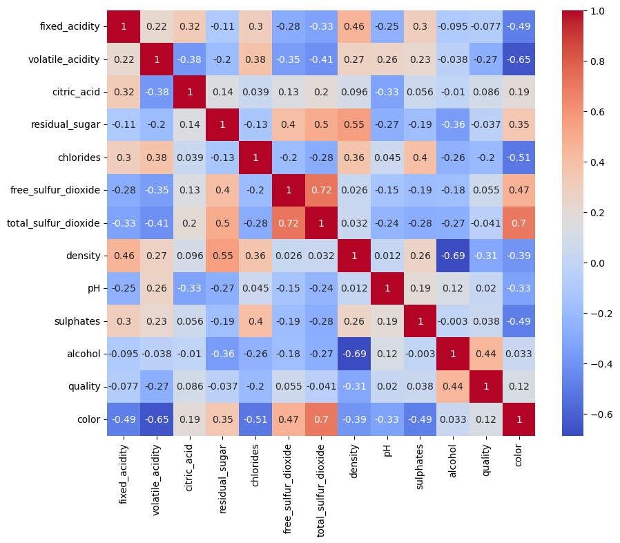